# Getting Started With R and RStudio

An opinionated guide to installing R, RStudio, and the Tidyverse

Author

Chuck Powell

Published

06-14-2024

## Installation – Half the battle

Getting all the necessary software installed, configured, and playing nicely together is honestly half the battle when first adopting `R` & `RStudio` (See Tip 1 for an explanation on what the difference is). Brace yourself for some pain. The upside is that you can give yourself a pat on the back once you get through this. And you **WILL** get through this.

**Important**

Working with R and RStudio users within DPH my experience is the number one impediment and the one I can least help you with is **NOT** having enough permission or user rights to install the software. If you are on a state owned machine or centrally managed computer, please make sure you have the ability to install software. In this tutorial you’re going to see examples and screenshots from my personal computers. I’ll highlight important differences across operating systems as they arise.

If you have some new problem and, especially, the corresponding solution, I’d love to hear from you!. These installation instructions are brand new, bear with me it’s the hardest part. Another important note is that I love live interaction, so don’t feel you have to wait to ask questions. Odds are if you have a question someone else does as well. Ask it.

**Note**

Note that this document is not meant to be the best single source set of instructions as a **“DIY”** resource. This document is meant as an outline and notes for a guided session.

This document is also very *opinionated* about the *best* way to use R/RStudio. There are plenty of other opinions so please don’t confuse my strong opinions with the *“one right way”* or the *“only way”*.

If you feel up to doing it yourself. [Here’s one possible](https://rstudio-education.github.io/hopr/starting.html) simple set of documentation. As well as a host of very simple instructions for using R and RStudio.

For these sessions I’m going to start with the assumption that you don’t have a current version of the software installed. It many cases you might be better served by doing a fresh new install rather than other options. We’ll address that in a bit in Section 10 for additional details.

## Install R

Already have R installed? **Hold on: This is a great time to make sure your R installation is current.** Check your current version like so:

```r
    R.version.string
```

```
#> [1] "R version 4.4.1 (2024-06-14)"
```

If your version is not 4.3.n or 4.4.n please skip to Section 10.

### Download a *pre-compiled binary* of `R` for your OS

From CRAN https://cloud.r-project.org (this will open a new tab in your browser). Without going into the geeky details please stick to *pre-compiled binaries*. `R` is open source and you can build it from scratch and look at every line of code if you like, but that’s not advisable for a newcomer.

Also if you see messages about an inability to “build packages” please ignore them for now. Almost every package you need is available without having to have `RTools`.

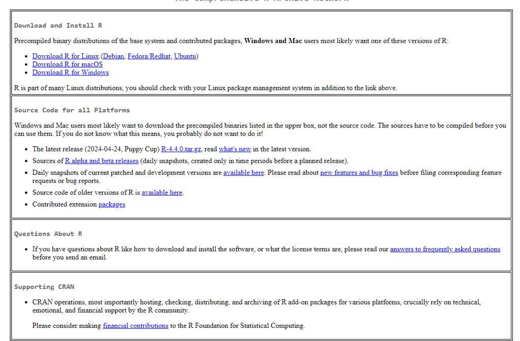

Screenshot showing CRAN download

Choose your operating system, in this example Windows and download it. **Please make sure you remember where** the downloaded installer is…

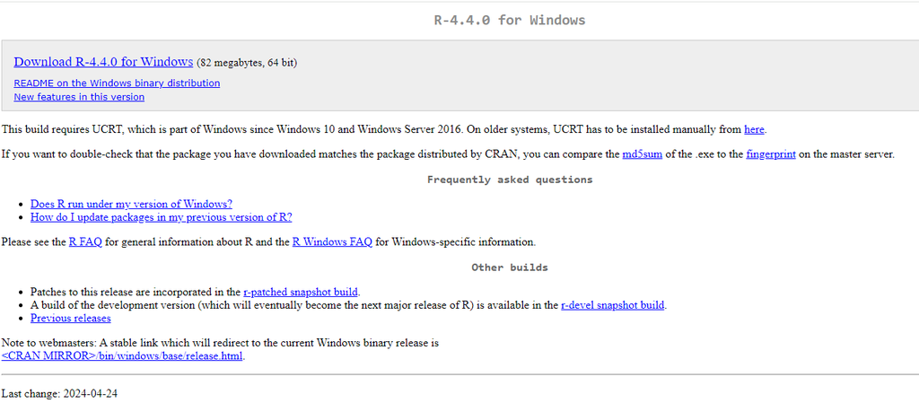

Screenshot showing CRAN download version

### Start the installer

Start the installation process by double clicking on the downloaded file. You are likely to get messages about allowing the software access.

The `R` installer comes with default settings that are quite rational but we’re going to make a few key tweaks during the process.

[figure not shown]

Screenshot showing Installer

**Important**

You may be tempted to install `R` on a network or virtual drive like `OneDrive`. I **strongly** discourage you from installing anywhere other than your local C: drive or other OS equivalent!

### Key installer options

As you install it (takes a few minutes) I recommend you *NOT* create a desktop shortcut nor a start folder for `R` itself because you are very unlikely to use it outside `RStudio`.

[figure not shown]

Screenshot showing options

[figure not shown]

Screenshot showing options

At the end of the installation process you should see the final message to finish. Please don’t be tempted to open it, run it, or otherwise interact with it yet. One more step first please.

## Install RStudio

Download RStudio Desktop. Already have RStudio? **Hold on: This is a great time to upgrade to the latest version.** Download it here: https://posit.co/download/rstudio-desktop/ you can check version numbers with “About RStudio”. If you have a recent version of `R` there is almost zero risk in updating `RStudio`.

Unless you are running `RStudio` in production for multiple users I recommend you upgrade to the latest version.

As with the `R` download make sure you remember where the installer is located.

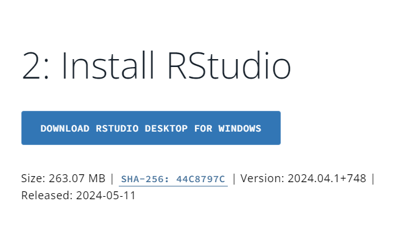

Screenshot showing RStudio download

### Start the installer

Start the installation process by double clicking on the downloaded file. You are likely to get messages about allowing the software access.

The `RStudio` installer comes with default settings that are quite rational but we’re going to make a few key tweaks during the process.

[figure not shown]

Screenshot showing Installer

### Key installer options

As you install it (takes a few minutes) I recommend you *DO* create a desktop shortcut and a start folder for `RStudio` itself because it’s a convenience.

[figure not shown]

Screenshot showing options

After you get familiar with the concept of [`projects`](https://docs.posit.co/ide/user/ide/get-started/#hello-rstudio-projects) it may not be your preferred method but it is handy to have it where you can easily find it.

## Are We There Yet?

No. But we are at a point where we can pause and see if what we have so far actually works!

Try starting `RStudio`. Not `R` (See Tip 1 for an explanation on what the difference is). If you’ve been following along I tried hard to hide the `R` icon so you don’t accidentally start that when you mean `RStudio`.

You will probably encounter this screen, take the default…

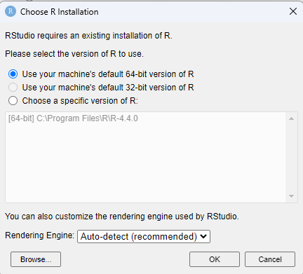

Screenshot showing which R prompt

`Posit` maintains [extensive doco on the IDE here](https://docs.posit.co/ide/user/ide/get-started/#hello-rstudio) It should look roughly like the following:

[figure not shown]

Screenshot showing RStudio panes

In the console window (the large left “pane”) type in or paste (See Tip 2 for more about cut and paste) in the following `sqrt(1:100) * 2`

**Important**

`R` and therefore `RStudio` are case sensitive. If you’re used to only MS Windows that may throw you for awhile! But `sqrt(1:100) * 2` is different than `Sqrt(1:100) * 2` the later with the capital “S” will earn you the message “`Error in Sqrt(1:100) : could not find function "Sqrt"`”

```r
  sqrt(1:100) * 2
```

```
#>   [1]  2.000000  2.828427  3.464102  4.000000  4.472136  4.898979  5.291503
#>   [8]  5.656854  6.000000  6.324555  6.633250  6.928203  7.211103  7.483315
#>  [15]  7.745967  8.000000  8.246211  8.485281  8.717798  8.944272  9.165151
#>  [22]  9.380832  9.591663  9.797959 10.000000 10.198039 10.392305 10.583005
#>  [29] 10.770330 10.954451 11.135529 11.313708 11.489125 11.661904 11.832160
#>  [36] 12.000000 12.165525 12.328828 12.489996 12.649111 12.806248 12.961481
#>  [43] 13.114877 13.266499 13.416408 13.564660 13.711309 13.856406 14.000000
#>  [50] 14.142136 14.282857 14.422205 14.560220 14.696938 14.832397 14.966630
#>  [57] 15.099669 15.231546 15.362291 15.491933 15.620499 15.748016 15.874508
#>  [64] 16.000000 16.124515 16.248077 16.370706 16.492423 16.613248 16.733201
#>  [71] 16.852300 16.970563 17.088007 17.204651 17.320508 17.435596 17.549929
#>  [78] 17.663522 17.776389 17.888544 18.000000 18.110770 18.220867 18.330303
#>  [85] 18.439089 18.547237 18.654758 18.761663 18.867962 18.973666 19.078784
#>  [92] 19.183326 19.287302 19.390719 19.493589 19.595918 19.697716 19.798990
#>  [99] 19.899749 20.000000
```

*Eureka!* it works! I know, you could take the square root of the integers from 1 to 100 and multiply by 2 on your phone but we’re through the hardest parts!

Exit `RStudio` and let’s proceed…

## Install the Quarto Command Line Interface

Install the `Quarto Command Line Interface`. **Hold on: Doesn’t RStudio already have Quarto?** Yes, but trust me, grab the latest, it will give you even more super powers to make reports and documents.

[Download it here](https://quarto.org/docs/get-started/)

[figure not shown]

**Please make sure you remember where** the downloaded installer is…

### Start the installer

Start the installation process by double clicking on the downloaded file. You are likely to get messages about allowing the software access.

[figure not shown]

Screenshot showing Installer

after the usual wait time you should be all set, we’ll check on it in a bit.

## Install a better package manager:

Which sort of begs the question, *“What’s a package and why do I need something better to manage them?”* The closest analogy is for commercial products like `SAS` or `SPSS` or even `Excel` which often offer a base edition and then other modules, or add-ins, sometimes for free, sometimes at additional cost. `Python` is also extensible in this manner.

You now have base `R` and `RStudio` installed (yes `RStudio` has add-ins too.), for many users that is more than enough for just about any statistical or data science usage. As a matter of fact, there are heated debates about why novices need to master base before messing with additional packages. Bearing in my mind my earlier note about this being an opinionated set of instructions we’re going in the opposite direction, installing some crucial packages and eschewing as much use of base `R` as we can.

So we’re going to use one base `R` command to install `pak` and then use `pak` for all future package installation. In the bottom right `RStudio` pane find and click on the “Packages” Tab, then click on the install tab…

Most of the info is pre-filled and correct just type in “pak” as shown…

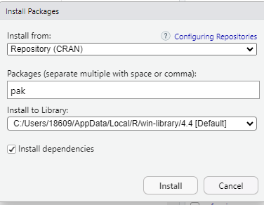

Screenshot showing RStudio packages tab

After a few seconds (given a decent internet connection) this will start to appear in the bottom left window…

[figure not shown]

Screenshot showing pak progress

**Again please feel free to ignore the warning message about `Rtools` required to build packages. At this point we’re going to stick to pre-built packages, much as we did for pre-built binaries**

In general, it is usually, safe to ignore “warnings” which are different than “errors”, more on that another day…

## Install the Tidyverse

Whew! Almost there! One last step until we have you up and ready.

There are thousands and thousands of packages available for `R` most on `CRAN`, some on other platforms like `GitHub` or `Bioconductor`, you can even make your own package and share it as a file.

We’re going to install about 100 packages known as the `Tidyverse`. The [homepage is here](https://www.tidyverse.org/).

**But first an important distinction!** In `R` there is a distinction between installing a package and making it available to “use”, every package you “install” is theoretically available for use, but to actually make use of an entire package and everything in it you type `library(pak)`. There are ways to pick and choose which pieces of which packages you use, but for now let’s keep it simple.

What happens next depends on the package, but in the case of `pak` it will simply return to the command prompt after an almost imperceptible delay.

But the next step is `pkg_install("tidyverse")`

```r
library(pak)
pkg_install("tidyverse")
```

This step will produce a very verbose output, as it first figures out what packages are required, what other packages are needed then downloads and installs all of them.

Here’s a sample of the screen about 80% of the way through:

[figure not shown]

Screenshot showing pak progress

## The Final Test

Alright, drumroll please…

Let’s make sure all that worked and we’re in good shape.

Happily this is much simpler than getting it all installed.

As I mentioned above let’s make all the pieces of the `tidyverse` available with the `library` command. Then let’s make a good looking plot with one of those components known as `ggplot2`.

**Note**

I can’t recommend `ggplot2` enough. Back in the early days of the `Tidyverse` it was one of the main attractions that beckoned people to install `tidyverse` components

`R` has a number of built in `datasets`, let’s use the one named `mpg` that is part of `ggplot2` to compare the highway mpg of various 4 cylinder cars. To learn more about about the built-in datasets type `library(help = "datasets")` in the console.

(Remember Tip 2 rather than doing all the typing yourself)

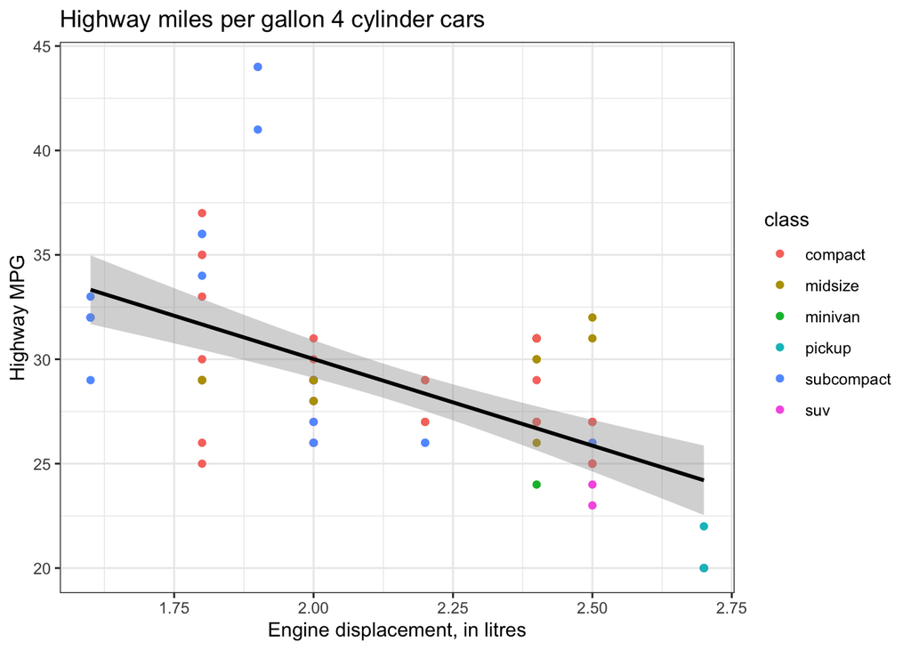

```r
library(tidyverse)
mpg %>%
  filter(cyl == 4) %>%
  ggplot(aes(x = displ, y = hwy)) +
    geom_point(mapping = aes(colour = class)) +
    geom_smooth(colour = "black",
                method = "lm",
                formula = "y ~ x") +
    xlab("Engine displacement, in litres") +
    ylab("Highway MPG") +
    ggtitle("Highway miles per gallon 4 cylinder cars") +
    theme_bw()
```

Voila! Over in the bottom right pane of `RStudio` is a tab labelled “Plots” and that’s where you should see the output.

Please note that the example is pretty trivial I mean yeah the larger the engine in liters the less the gas mileage but the example is very illustrative of `Tidyverse` consistency of grammar and syntax and workflow.

We took the `mpg` dataset and using `%>%` we “sent” (often referred to as piping and keyboard shortcut `CTRL SHIFT M`) it to further steps. We used `filter(cyl == 4)` to chose only the rows of data for 4 cylinder cars. We took that subset of data and send if off to `ggplot2` with `ggplot(aes(x = displ, y = hwy))` put the `displ` variable on the x axis and `hwy` on the y axis. The code `geom_point(mapping = aes(colour = class)) +` says add a layer to the plot (hence the plus sign) that shows the individual data points, and colors them according to `class`. The `geom_smooth()` is a bit of magic that says compute the linear model that predicts `hwy` using `displ` (i.e. linear regression using “least squares”), draw the line in the color “black” and plot the confidence interval for that line in gray. The rest is just changing the labels, the title, and the overall theme.

## Daily Usage

*Congratulations* You’re all set to use RStudio anytime you need it.

When we installed RStudio I mentioned the concept of [`projects`](https://docs.posit.co/ide/user/ide/get-started/#hello-rstudio-projects) now is a good time to review that, decide where you want your projects to “live” and start making use of them.

## Starting Over

What happens if you have an existing installation of `R` or `RStudio`?

**Get current, people.** You don’t want to adopt new things on day one. But at some point, running old versions of software adds unnecessary difficulty.

Each major version is followed by about a year of smaller releases (minor and patch releases). You can be more relaxed about upgrading minor versions, but you still want to stay reasonably current. As the 4.something series unfolds, I advise that you never fall more than 1 minor version behind.

Is your RStudio “old”? Unless you have a specific reason to prefer otherwise, always install the latest updates. RStudio is fairly conservative with official releases, so the Preview version is used by many people for their daily work. This allows you to enjoy the latest goodies much sooner. The Preview version updates much more frequently (and in smaller increments) than the released version. This is something you might update once every month or so.

## Helpful Tips

**Tip 1: What’s the difference between `R` and `RStudio`**

`R` refers to programming language like `Python` or `Java`, or …

`RStudio` is an integrated development environment. As the name implies it started as uniquely aimed for `R` but has now expanded to include other languages like `Python`.

To make things simpler I recommend you don’t worry about which name you use most of the time, but always use RStudio as your gateway to all things R. More on that in a bit.

**Tip 2: You can cut and paste**

These instructions were written entirely in `R` and `RStudio` and then “rendered” into an `html` document (`pdf` and `word` are also possible) using `Quarto`. Besides the professional looking output one of the true advantages is that you can easily cut and paste from the html into RStudio to “try” the examples.

Trying to cut and paste from `MS Word` is usually disastrous, way too many proprietary formatting glitches.

fini